# Trabajo FInal

Alejandro Bermúdez Gómez y Diego Fuentes

2023-11-28

**1. Crea un dataframe con los datos del archivo SSAinfo.csv (tiene encabezados)**

```r
pacientes <- read.csv("SSAinfo.csv", as.is = FALSE)
```

**2. Muestra la estructura de los datos y clasifica cada atributo en Cualitativo: Nominal u Ordinal y Cuantitativo: Continuo o Discreto**

```r
str(pacientes)
```

```
## 'data.frame':    31180 obs. of  9 variables:
##  $ estado      : Factor w/ 32 levels "Aguascalientes",..: 1 1 1 1 1 1 1 1 1 1 ...
##  $ sexo        : Factor w/ 2 levels "Femenino","Masculino": 2 2 2 2 2 1 2 2 2 2 ...
##  $ edad        : int  18 44 51 26 26 47 50 54 45 37 ...
##  $ peso        : int  77 83 80 65 70 60 80 70 75 82 ...
##  $ altura      : int  174 171 174 170 165 165 174 165 170 174 ...
##  $ diasEstancia: int  56 53 51 45 43 29 25 24 21 21 ...
##  $ anioIng     : int  2015 2015 2015 2014 2015 2015 2015 2015 2015 2015 ...
##  $ mesIng      : Factor w/ 12 levels "Abril","Agosto",..: 11 11 4 3 12 12 10 8 10 5 ...
##  $ accidente   : Factor w/ 9 levels "AREA INDUSTRIAL Y DE LA CONSTRUCCION",..: 7 7 7 7 7 7 7 7 7 7 ...
```

*Cualitativo.*

*Nominal: estado, sexo, año de ingreso, mes de ingreso, accidente*

*Cuantitativo.*

*Continuo: peso y altura.*

*Discreto: edad y dias de estancia*

**3. Muestra la frecuencia absoluta por estado, responde cuáles Estados de la República tienen más de 1000 pacientes**

```r
cbind(FAbs = table(pacientes$estado))
```

```
##                     FAbs
## Aguascalientes        71
## Baja California      641
## Baja California Sur  419
## Campeche             363
## Chiapas             1922
## Chihuahua           1401
## Ciudad de Mexico    1082
## Coahuila             823
## Colima               113
## Durango             1049
## Guanajuato           112
## Guerrero             529
## Hidalgo               32
## Jalisco              636
## Mexico              6402
## Michoacan           2518
## Morelos             1116
## Nayarit              446
## Nuevo Leon            53
## Oaxaca                77
## Puebla              4188
## Queretaro           1217
## Quintana Roo        1005
## San Luis PotosI      832
## Sinaloa             1018
## Sonora                 5
## Tabasco             1494
## Tamaulipas            20
## Tlaxcala             406
## Veracruz             625
## Yucatan              392
## Zacatecas            173
```

**4. De los estados de tu respuesta elige 6 para crear un nuevo dataframe, que contendrá pacientes entre 20 y 50 años. Ocupa las siguientes instrucciones, ajustando los valores**

```r
pacientesN <- subset(pacientes, edad %in% c(18:48) &
                     estado %in% c("Chiapas", "Chihuahua", "Ciudad de Mexico",
                                   "Durango", "Mexico", "Michoacan"))

#Elimina los estados con frecuencia cero.
pacientesN$estado <- factor(pacientesN$estado)
```

**5. Convierte mesIng en un dato de tipo ordinal**

```r
meses <- c("Enero", "Febrero", "Marzo", "Abril", "Mayo", "Junio", "Julio",
           "Agosto", "Septiembre", "Octubre", "Noviembre", "Diciembre")

pacientesN$mesIng <- ordered(pacientesN$mesIng, meses)
```

**6. Agrega la columna de imc al dataframe para esto realiza la siguiente instrucción: nombre_dataframe$imc = formula_imc (cuida unidades)**

```r
#La altura está en centímetros

pacientesN$imc = pacientesN$peso / ((pacientesN$altura / 100) ^ 2)
```

**7. Muestra el resumen de los datos (deben ser similares pero no iguales)**

```r
summary(pacientesN)
```

```
##               estado            sexo           edad            peso
##  Chiapas         :1489   Femenino :9153   Min.   :18.00   Min.   : 37.00
##  Chihuahua       :1007   Masculino:1757   1st Qu.:21.00   1st Qu.: 57.00
##  Ciudad de Mexico: 811                    Median :26.00   Median : 60.00
##  Durango         : 829                    Mean   :28.24   Mean   : 63.14
##  Mexico          :5025                    3rd Qu.:34.00   3rd Qu.: 68.00
##  Michoacan       :1749                    Max.   :48.00   Max.   :190.00
##
##      altura       diasEstancia       anioIng            mesIng
##  Min.   :100.0   Min.   :  0.00   Min.   :2014   Octubre   : 988
##  1st Qu.:154.0   1st Qu.:  1.00   1st Qu.:2014   Agosto    : 975
##  Median :160.0   Median :  1.00   Median :2014   Septiembre: 964
##  Mean   :158.9   Mean   :  2.21   Mean   :2014   Julio     : 960
##  3rd Qu.:164.0   3rd Qu.:  2.00   3rd Qu.:2015   Junio     : 942
##  Max.   :200.0   Max.   :156.00   Max.   :2015   Marzo     : 939
##                                                  (Other)   :5142
##                         accidente          imc
##  NO APLICA                   :10285   Min.   : 13.44
##  LUGAR NO ESPECIFICADO       :  291   1st Qu.: 22.60
##  CALLES Y CARRETERAS         :  162   Median : 24.22
##  VIVIENDA                    :  121   Mean   : 25.06
##  OTRO LUGAR ESPECIFICADO     :   22   3rd Qu.: 26.71
##  AREAS DE DEPORTE Y ATLETISMO:   12   Max.   :145.16
##  (Other)                     :   17
```

**8. Genera el boxplot para conocer la distribución del peso por sexo, usa unidades, nombres en ejes y agrega la media**

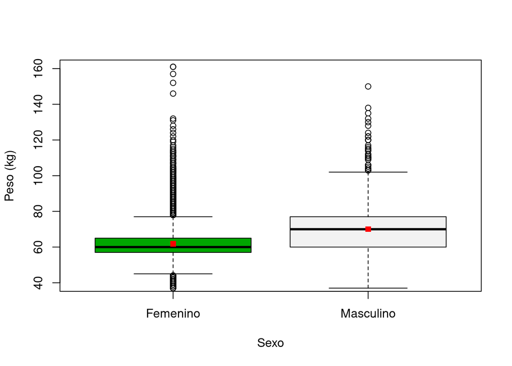

```r
attach(pacientesN)

boxplot(peso~sexo,
        xlab = "Sexo", ylab = "Peso (kg)",
        col = terrain.colors(2),
        ylim = c(40, 160))

medias <- tapply(peso, sexo, mean)

points(medias, col = "red", pch = 15)
```

**9. Obtén la matriz de correlación**

```r
medidas <- data.frame(peso, altura, edad)

cor(medidas)
```

```
##             peso    altura      edad
## peso   1.0000000 0.3673732 0.1713869
## altura 0.3673732 1.0000000 0.1523797
## edad   0.1713869 0.1523797 1.0000000
```

**10. Realiza el diagrama de dispersión de las 2 variables con mayor correlación, responde qué pasa si una aumenta**

La variables con mayor correlación son peso-altura y edad-peso

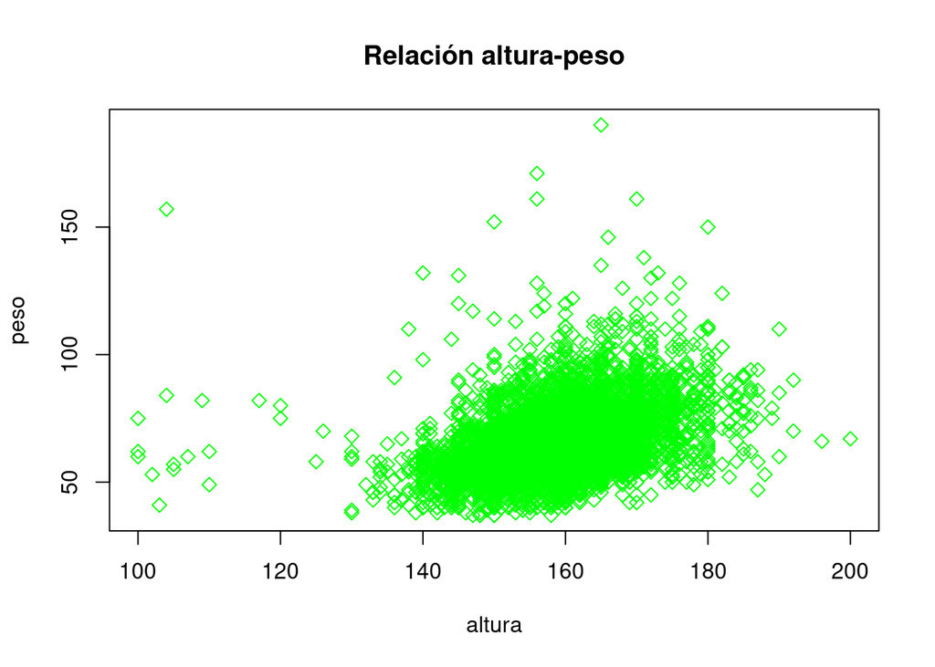

```r
#peso-altura
plot(altura, peso, pch = 5, col = "green")
title("Relación altura-peso")
```

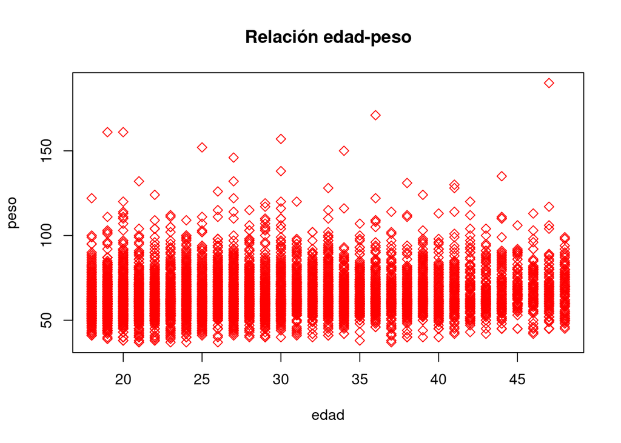

```r
#edad-peso
plot(edad, peso, pch = 5, col = "red")
title("Relación edad-peso")
```

**11. Analiza los resultados del boxplot y correlación, comenta que te llama la atención en lo esperado y tal vez lo no esperado.**

*Era de esperarse que los hombres pesarán más que las mujeres. Así como también que existan valores atípicos en la gráfica de Turkey, los cuales representan personas con obesidad o anorexia, pero no se esperaba que sean más los casos en mujeres que en hombres. De hecho, los casos de anorexia se presentan solo en mujeres.*

**12. Muestra el número de pacientes por estado en un gráfico de barras**

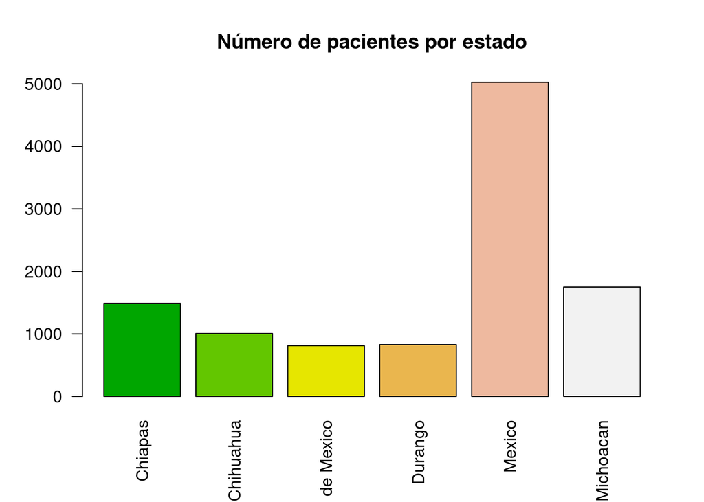

```r
barplot(table(estado),
        main = "Número de pacientes por estado",
        col = terrain.colors(6),
        las = 2)
```

**13. Divide las edades en rangos de 5 años y obtén la frecuencia absoluta, acumulada y relativa en esos rangos de años.**

```r
summary(edad)
```

```
##    Min. 1st Qu.  Median    Mean 3rd Qu.    Max.
##   18.00   21.00   26.00   28.24   34.00   48.00
```

```r
#El mínimo es de 18 y el máximo es de 48, cortamos la edad de 5 en 5.
intervalo <- seq(18, 48, by = 5)

intEdad <- cut(edad, intervalo, right = FALSE)

fedad <- table(intEdad)

cbind(FAbs = fedad, FAcum = cumsum(fedad), FRel = round(prop.table(fedad),
                                                        digits = 2))
```

```
##         FAbs FAcum FRel
## [18,23) 3454  3454 0.32
## [23,28) 2589  6043 0.24
## [28,33) 1777  7820 0.16
## [33,38) 1259  9079 0.12
## [38,43)  951 10030 0.09
## [43,48)  752 10782 0.07
```

**14. Muestra la frecuencia porcentual con 1 decimal, de los rangos de edades en un gráfico circular. ¿Hay alguna tendencia?**

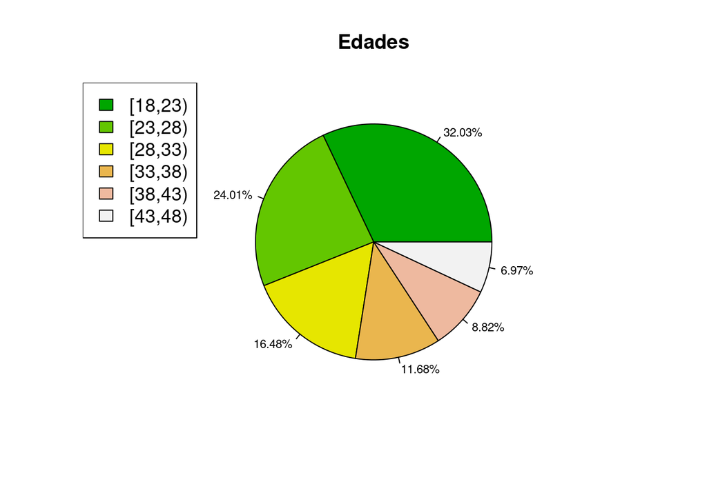

```r
porcentaje <- prop.table(fedad)

etiquetas <- paste(round(porcentaje * 100, 2), "%", sep = "")

pie(fedad,
    main = "Edades",
    col = terrain.colors(6),
    labels = etiquetas,
    cex = 0.7)

legend("topleft", rownames(fedad), fill = terrain.colors(6), cex = 1.1)
```

*Los pacientes tienden a tener entre 18 y 23 años de edad*

**15. Obtén un gráfico de barra por estado con la edad de los pacientes. ¿Las edades tienen el mismo comportamiento por estado?**

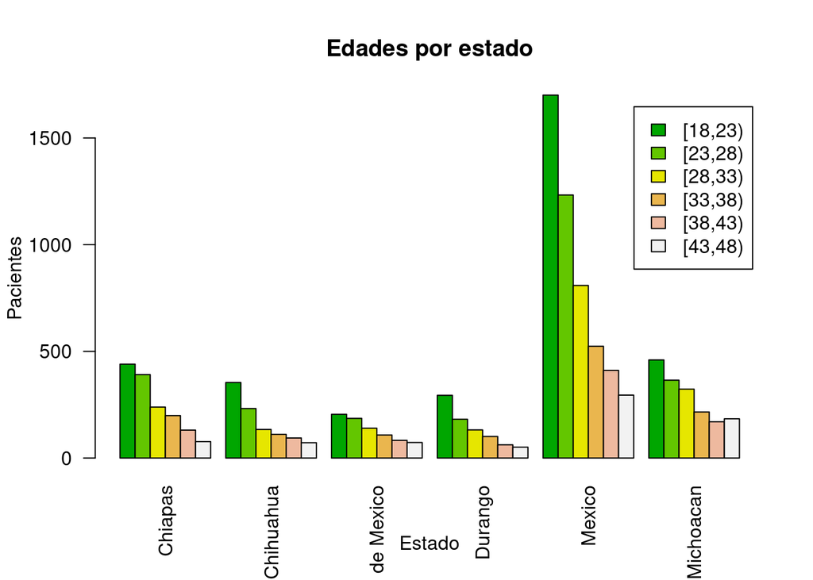

```r
fedad2 <- table(intEdad, estado)

barplot(fedad2,
        main = "Edades por estado",
        col = terrain.colors(6),
        xlab = "Estado", ylab = "Pacientes",
        legend = rownames(fedad2),
        beside = TRUE,
        las = 2)
```

**16. Muestra el coeficiente de variación por cada rango de edad, ¿Cuál es el menos consistente?**

```r
tapply(peso, intEdad, sd) * 100 / tapply(peso, intEdad, mean)
```

```
##  [18,23)  [23,28)  [28,33)  [33,38)  [38,43)  [43,48)
## 15.60042 16.56270 17.68603 18.33087 18.59862 18.69782
```

**17. Muestra la distribución en barras apiladas del ingreso mensual de pacientes por año**

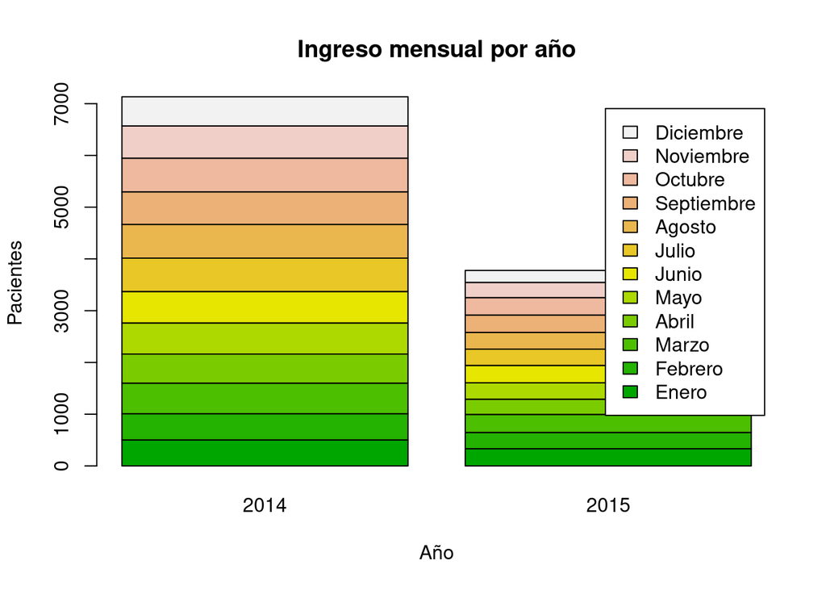

```r
ingreso <- table(mesIng, anioIng)

barplot(ingreso,
        main = "Ingreso mensual por año",
        col = terrain.colors(12),
        xlab = "Año", ylab = "Pacientes",
        legend = rownames(ingreso))
```

**18. Usa la frecuencia proporcional de ingreso mensual para responder si hay gran diferencia de ingresos hospitalarios en algún mes.**

```r
cbind(FPor = round(prop.table(table(mesIng)) * 100, 2))
```

```
##            FPor
## Enero      7.66
## Febrero    7.52
## Marzo      8.61
## Abril      7.86
## Mayo       8.41
## Junio      8.63
## Julio      8.80
## Agosto     8.94
## Septiembre 8.84
## Octubre    9.06
## Noviembre  8.41
## Diciembre  7.27
```

*No la hay*

**19. Compara los días de estancia por sexo, usa un boxplot que incluya la media, comenta los hallazgos.**

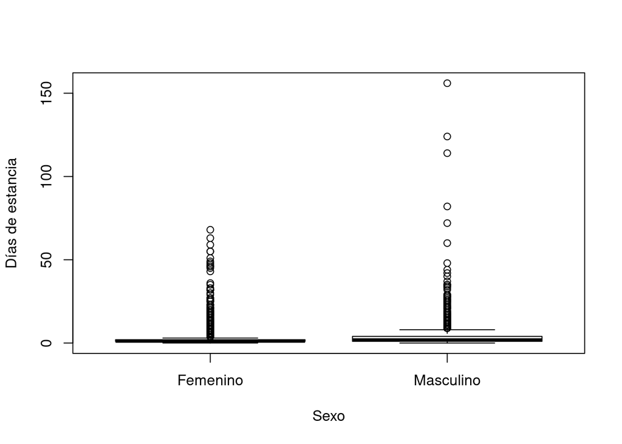

```r
boxplot(diasEstancia~sexo,
        col = terrain.colors(2),
        xlab = "Sexo", ylab = "Días de estancia")
```

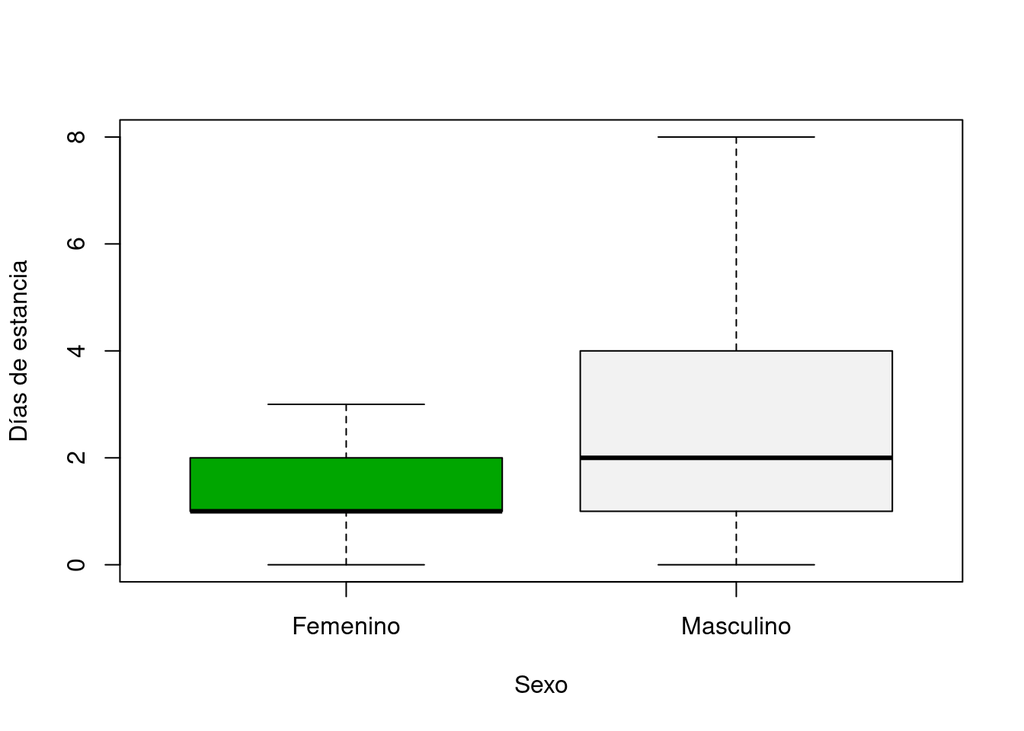

```r
boxplot(diasEstancia~sexo,
        col = terrain.colors(2),
        xlab = "Sexo", ylab = "Días de estancia",
        outline = FALSE)
```

**20. Compara la estatura por estado con un boxplot. Si se obtienen outlier(valor atípico) quítalos y vuelve a crear el boxplot, enfatiza la mediana.**

**a) ¿Cuál estado tiene el mayor rango y cuál el menor?**

**b) El Q2 de algún estado está en el Q3 de otro, si es así en cuáles**

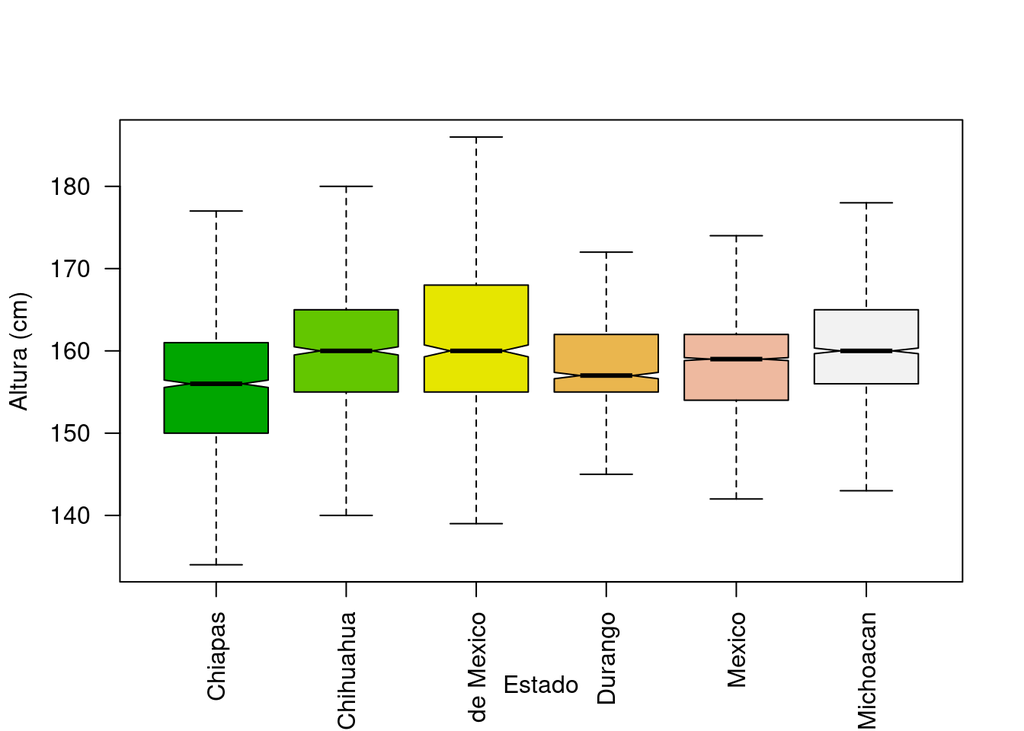

```r
boxplot(altura~estado,
        notch = TRUE,
        outline = FALSE,
        col = terrain.colors(6),
        xlab = "Estado", ylab = "Altura (cm)",
        las = 2)
```

*b) El cuartil 2 de Michoacan se encuentra en el cuartil 3 de Durango*

**21. Haz el histograma para las alturas de los pacientes, con los intervalos de default. En cuál intervalo está la moda.**

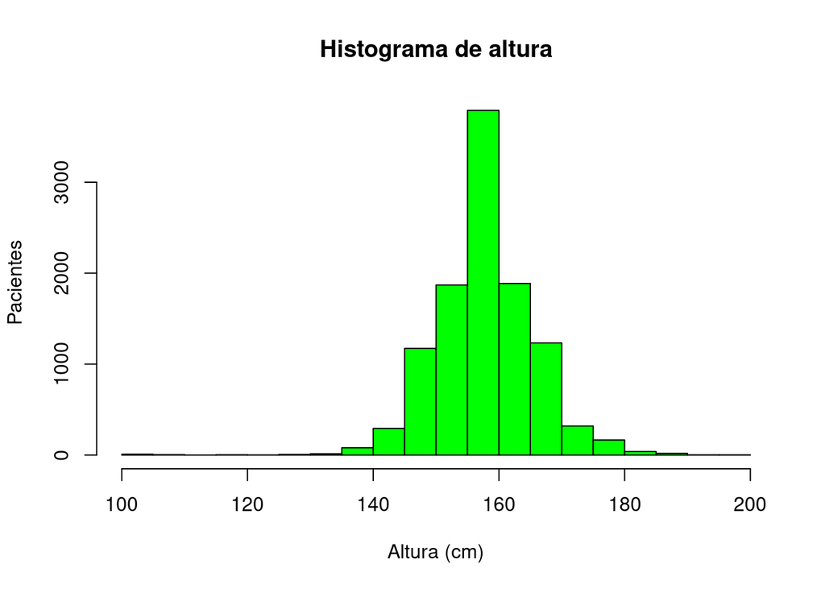

```r
hist(altura,
     main = "Histograma de altura",
     col = "green",
     xlab = "Altura (cm)", ylab = "Pacientes")
```

**22. Obtén la media y la mediana e indica qué sesgo tienen los datos**

```r
mean(altura)
```

```
## [1] 158.8619
```

```r
#Mode(altura)

summary(altura)
```

```
##    Min. 1st Qu.  Median    Mean 3rd Qu.    Max.
##   100.0   154.0   160.0   158.9   164.0   200.0
```

**23. Muestra la frecuencia acumulada de altura usando los intervalos sugeridos por el histograma**

```r
#Creamos los intervalos
intervalo <- seq(100, 200, by = 20)

alturaInt <- cut(altura, intervalo, right = FALSE)

faltura <- table(alturaInt)

FAcum <- cumsum(faltura)

cbind(FAcum)
```

```
##           FAcum
## [100,120)    14
## [120,140)    66
## [140,160)  5359
## [160,180) 10787
## [180,200) 10909
```

**24. Realiza los pasos faltantes para graficar la ojiva**

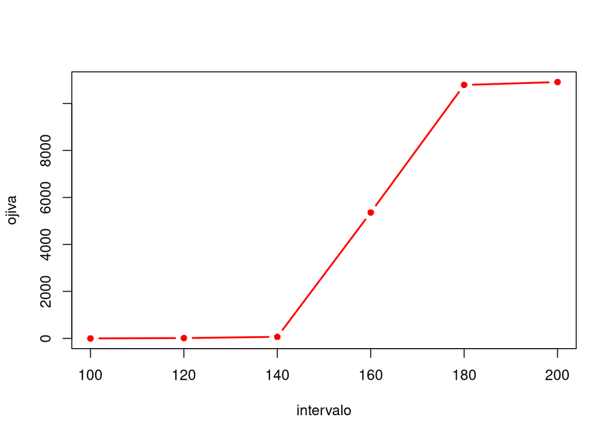

```r
ojiva <- c(0, FAcum)

plot(intervalo, ojiva, type = "p", pch = 16, col = "red")

lines(intervalo, ojiva, type = "c", lwd = 2, col = "red")
```

**25. En el archivo imc_oms.gif, se encuentran la tabla de clasificación de peso de la Organización Mundial de la Salud (OMS). Utiliza estos y el rango de valores del imc para crear los intervalos apropiados a cada clasificación.**

```r
intervalo <- c(10, 18.5, 25, 30, 35, 40, 90)
```

**26. Calcula las frecuencias absolutas y porcentuales por cada intervalo**

```r
imcInt <- cut(imc, intervalo, right = FALSE, dig.lab = 2)

fimc <- table(imcInt)

cbind(FAbs = fimc, FPor = round(prop.table(fimc) * 100, 2))
```

```
##         FAbs  FPor
## [10,18)  197  1.81
## [18,25) 6450 59.13
## [25,30) 3229 29.60
## [30,35)  749  6.87
## [35,40)  197  1.81
## [40,90)   87  0.80
```

**27. Muestra el histograma**

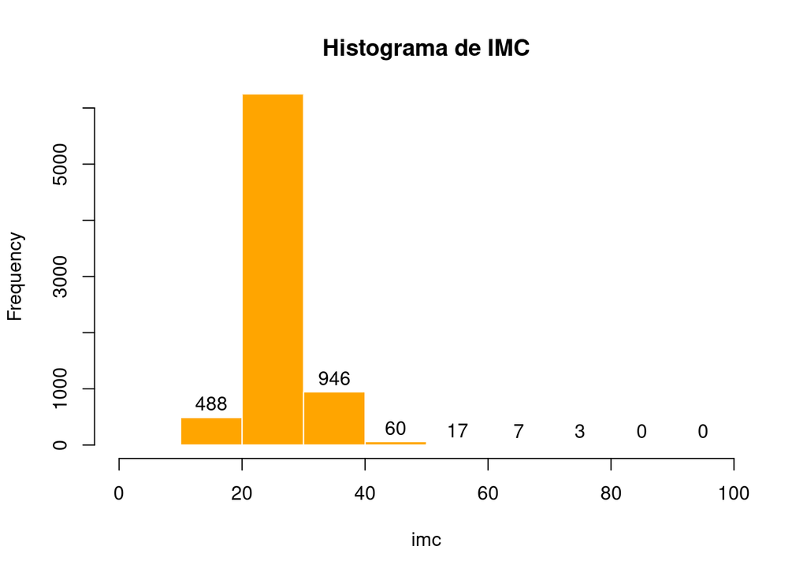

```r
hist(imc,
     xlim = c(0, 100), ylim = c(0, 6000),
     main = "Histograma de IMC",
     xlabel = "IMC", ylabel = "Pacientes",
     col = "orange",
     border = "white",
     freq = TRUE,
     labels = TRUE)
```

**28. Crea un vector con el nombre de cada clasificación**

```r
oms = c("Bajo peso", "Normal", "Sobrepeso", "Obesidad grado I", "Obesidad grado
        II", "Obesidad grado III")
```

**29. Realiza los pasos necesarios para generar el gráfico de barras apiladas por clasificación de la OMS (intervalo) para cada estado, la instrucción final debe ser similar a:**

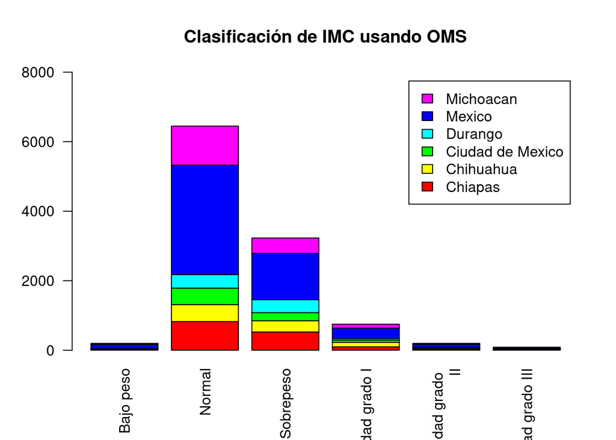

```r
testadoimc <- table(estado, imcInt)

barplot(testadoimc,
        main = "Clasificación de IMC usando OMS",
        col = rainbow(6),
        ylim = c(0, 8000),
        names = oms,
        las = 2,
        legend = rownames(testadoimc))
```

**30. Repite el mismo procedimiento pero ahora de la clasificación de la OMS por sexo.**

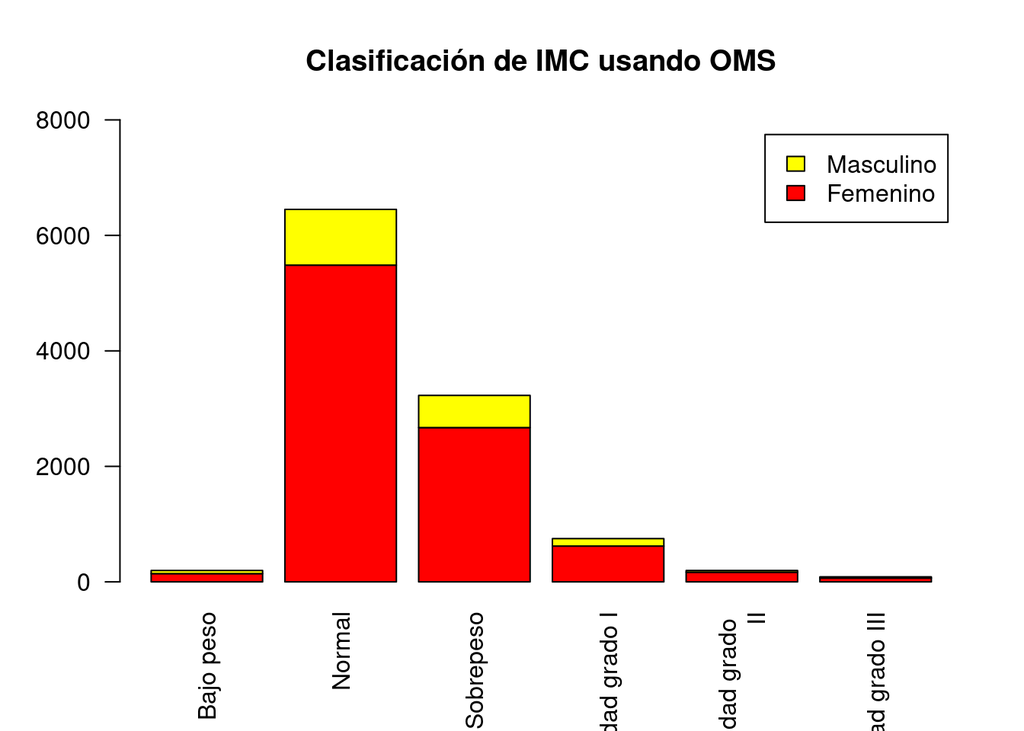

```r
tsexoimc <- table(sexo, imcInt)

barplot(tsexoimc,
        main = "Clasificación de IMC usando OMS",
        col = rainbow(6),
        ylim = c(0, 8000),
        names = oms,
        las = 2,
        legend = rownames(tsexoimc))
```

**31. Compara las frecuencias proporcionales. ¿Se puede concluir con estos datos que las mujeres sufren más de sobrepeso que los hombres?**

```r
so <- table(imcInt, sexo)

round(prop.table(so) * 100, 2)
```

```
##          sexo
## imcInt    Femenino Masculino
##   [10,18)     1.31      0.50
##   [18,25)    50.28      8.85
##   [25,30)    24.49      5.11
##   [30,35)     5.68      1.18
##   [35,40)     1.53      0.28
##   [40,90)     0.60      0.20
```

*No se puede concluir en la tabla que las mujeres padecen más de sobrepeso que los hombres. Además de que en la tabla no están nombradas la clasificaciones por intervalo, la tabla considera a toda la población, donde las mujeres son mayoría, por lo tanto, no podemos saber si el porcentaje de mujeres que padecen sobrepeso con respecto a la población de mujeres es mayor que el de los hombres*

**32. Crea una paleta de colores, para cada uno de los niveles de IMC de la OMS.**

```r
colimc <- c("navy", "green", "yellow", "orange", "red", "darkred")
```

**33. Crea un nuevo dataframe, que contiene únicamente los datos de imc de las mujeres, con la instrucción mostrada.**

```r
fem <- subset(pacientesN, sexo == "Femenino", select = imc)
```

**34. Con esta información crea el gráfico de pastel. El parámetro “intervalo” corresponde al nombre del vector usado para guardar los intervalos de imc de la OMS.**

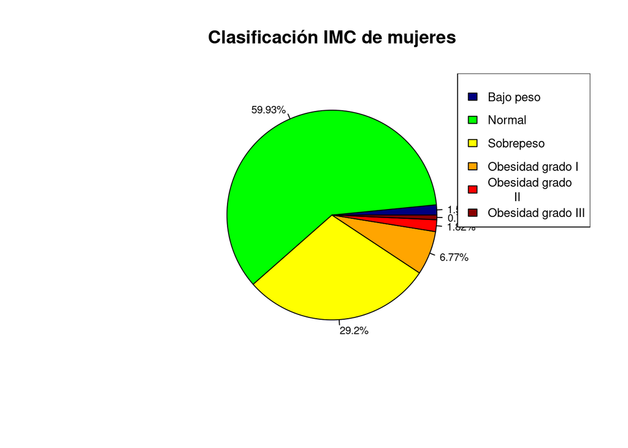

```r
cfem <- cut(fem$imc, intervalo, right = FALSE)
ffem <- table(cfem)
pctfem <- prop.table(ffem)

etiquetas <- paste(round(pctfem * 100, 2), "%", sep = "")
pie(pctfem, main = "Clasificación IMC de mujeres", col = colimc, labels = etiquetas, cex = 0.7)

legend("topright", legend = oms, fill = colimc, cex = 0.8)
```

**35. Repite el procedimiento para obtener el gráfico de pastel de los hombres. Responde ¿se puede concluir con estos datos que las mujeres sufren más de sobrepeso que los hombres?**

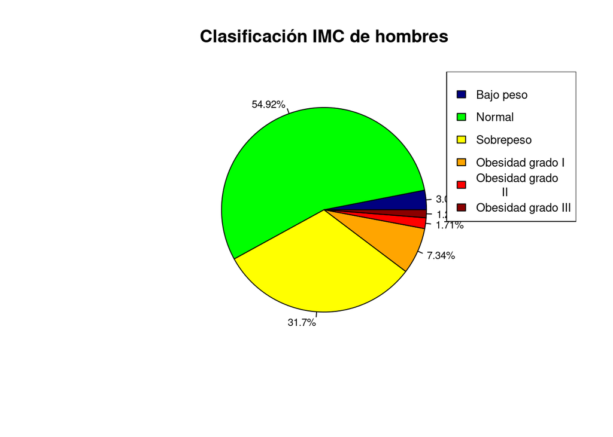

```r
mas <- subset(pacientesN, sexo == "Masculino", select = imc)

cmas <- cut(mas$imc, intervalo, right = FALSE)

fmas <- table(cmas)

pctmas <- prop.table(fmas)

etiquetas <- paste(round(pctmas * 100, 2), "%", sep = "")

pie(pctmas, main = "Clasificación IMC de hombres", col = colimc, labels = etiquetas, cex = 0.7)

legend("topright", legend = oms, fill = colimc, cex = 0.8)
```

*Con base en las gráficas anteriores, donde en cada una se puede ver el porcentaje de mujeres y de hombres que padecen sobrepeso con respecto a su población por separado, si podemos concluir que las mujeres no padecen más sobrepeso que los hombres*

**36. A partir del dataframe original crea otro que contenga todos los registros menos aquellos que en accidente dice “NO APLICA”, usa las siguientes instrucciones.**

```r
nuevo <- subset(pacientes, accidente != "NO APLICA")

nuevo$accidente <- factor(nuevo$accidente)
```

**37. Crea un mosaico ocupando el nuevo dataframe para mostrar el lugar de accidentes por sexo.**

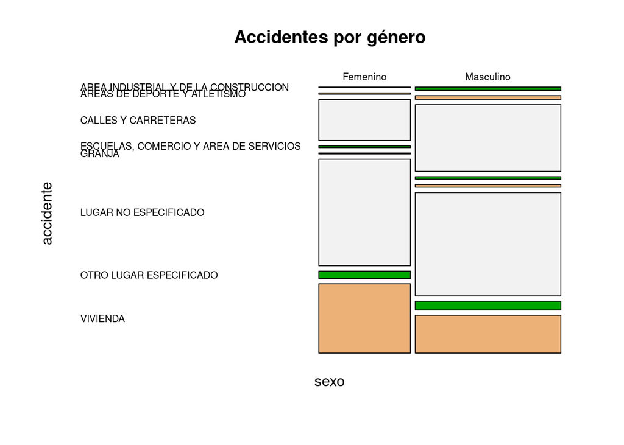

```r
detach(pacientesN)

attach(nuevo)

tsexoaccidente <- table(sexo, accidente)

mosaicplot(tsexoaccidente,
           las = 1,
           main = "Accidentes por género",
           color = terrain.colors(3),
           border = "black")
```

**38. Comenta los resultados, quienes sufren de más accidentes en general, y si hay rubros donde te parezca congruente la predominancia de hombres o mujeres.**

*Los hombres, en general, sufren más accidentes que las mujeres. Debido a incómodas dinámicas sociales, me parece congruente que los hombres padezcan accidentes en áreas industriales o de atletismo, mientras que las mujeres padecen más accidentes domésticos.*

**39. Realiza el mismo análisis pero ahora de accidente por edad. Recuerda comentar los resultados.**

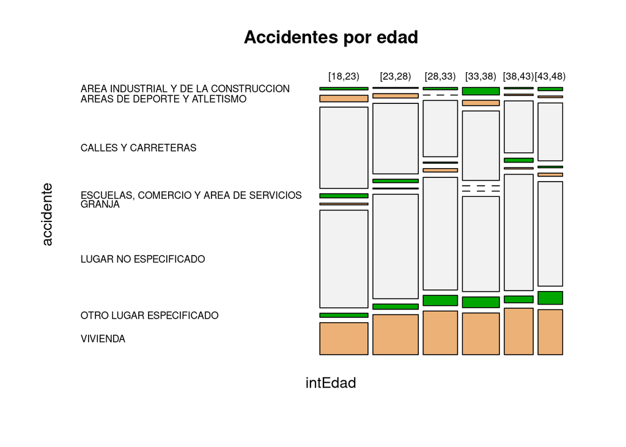

```r
intervalo <- seq(18, 48, by = 5)

intEdad <- cut(edad, intervalo, right = FALSE)

tedadaccidente <- table(intEdad, accidente)

mosaicplot(tedadaccidente,
           las = 1,
           main = "Accidentes por edad",
           color = terrain.colors(3),
           border = "black")
```

*Los más propensos a padecer accidentes son los jóvenes entre 18 y 28 años, en lugares que no son hogar, especialmente la carretara. Entre más viejo y sedentario se hace uno es más propenso a padecer accidentes en el hogar*

**40. Con cualquiera de los conjuntos de datos crea otros 2 gráficos que te parezcan interesantes, indica qué pregunta responden.**

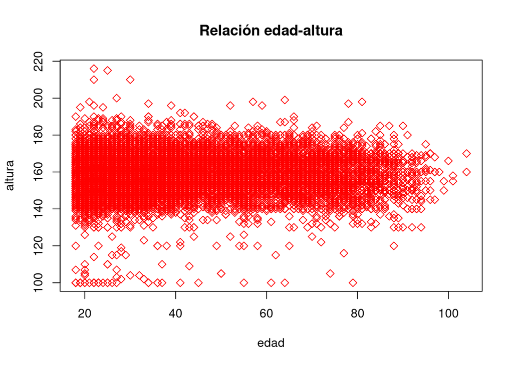

```r
detach(nuevo)

attach(pacientes)

plot(edad, altura, pch = 5, col = "red",)

title("Relación edad-altura")
```

*Puede parecer simple, pero es la altura por edad.*

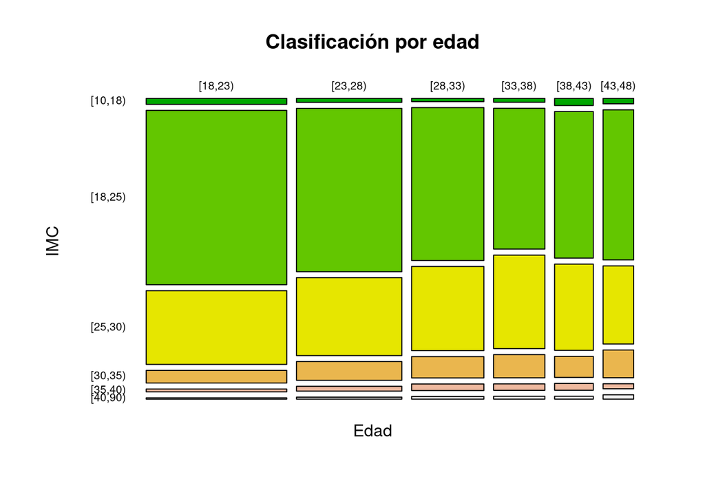

```r
detach(pacientes)

attach(pacientesN)


pesos <- c(10, 18.5, 25, 30, 35, 40, 90)

edades <- seq(18, 48, by = 5)


imcInt <- cut(imc, pesos, right = FALSE, dig.lab = 2)

edadInt <- cut(edad, edades, right = FALSE)


tedadimc <- table(edadInt, imcInt)


mosaicplot(tedadimc,
           las = 1,
           main = "Clasificación por edad",
           xlab = "Edad", ylab = "IMC",
           col = terrain.colors(6),
           border = "black")
```

*Con esta gráfica podemos saber qué edades padecen más de sobrepeso*